# Lab 2: Spatial Analysis and Visualization

Healthcare Access and Equity in Pennsylvania

Author

Shubhanga Satyal

Published

February 23, 2026

## Assignment Overview

**Learning Objectives:** - Apply spatial operations to answer policy-relevant research questions - Integrate census demographic data with spatial analysis - Create publication-quality visualizations and maps - Work with spatial data from multiple sources - Communicate findings effectively for policy audiences

## Part 1: Healthcare Access for Vulnerable Populations

### Research Question

**Which Pennsylvania counties have the highest proportion of vulnerable populations (elderly + low-income) living far from hospitals?**

### Analysis Steps

#### Step 1: Data Collection

```r
# Load required packages - loaded all packages I could
library(tidyverse)
library(tidycensus)
library(scales)
library(RColorBrewer)
library(sf)
library(tidyverse)
library(tigris)
library(tidycensus)
library(scales)
library(patchwork)
library(knitr)


# Load spatial data
pa_counties <- st_read("data/Pennsylvania_County_Boundaries.shp")
hospitals <- st_read("data/hospitals.geojson")
census_tracts <- tracts(state = "PA", cb = TRUE)


#Transformed to Same County
hospitals <- st_transform(hospitals, st_crs(pa_counties))
census_tracts <- st_transform(census_tracts, st_crs(pa_counties))


# Checking that all data loaded correctly
head(pa_counties)
head(hospitals)
head(census_tracts)
head(census_tracts)


#summarizing to see what Projection is used
summarise(pa_counties)
```

[output not shown]

**Questions to answer:**.

- **How many hospitals are in your dataset?**.

  223
- **How many census tracts?**.

  3,345
- **What coordinate reference system is each dataset in?**.

  All use WGS 84 after I transformed the coordinate system.

#### Step 2: Get Demographic Data

```r
# Get demographic data from ACS
demographic_data <- get_acs(
  geography = "tract",
  state = "PA",
  variables = c(
    total_population = "B01003_001",
    median_income = "B19013_001",
#used chatgpt to get tables for all male and female categries above 65
    a = "B01001_020",
    b = "B01001_021",
    c = "B01001_022",
    d = "B01001_023",
    e = "B01001_024",
    f = "B01001_025",
    g = "B01001_044",
    h = "B01001_045",
    i = "B01001_046",
    j = "B01001_047",
    k = "B01001_048",
    l = "B01001_049"
  ),
  year = 2022,
  survey = "acs5",
  output = "wide"
) %>%
#adding all categories for 65+ populations to create and aggregate whole.
  mutate(
    pop_65plusE =
      aE + bE + cE + dE + eE + fE + gE + hE + iE + jE + kE + lE
      ) %>%
#removing excess strings (words) to make data more presentable
  mutate(
    NAME = NAME %>%
      str_remove("Census Tract ") %>%
      str_remove("; Pennsylvania")
  )%>%
#selecting what to present
  select(
    GEOID,
    `County Name` = NAME,
    `Total Population` = total_populationE,
    `Total Population 65 Y+` = pop_65plusE,
    `Median HH Income` = median_incomeE
  )


#presenting only the first six rows to check for data
head(demographic_data)


#using left_join to join demographic data to census tracts using common GEOID
join_tract_boundaries <- census_tracts %>%
  left_join(demographic_data, by = "GEOID")


#viewing the first six rows of the new joined data
head(join_tract_boundaries)


#summarising only the median household income data
join_tract_boundaries%>%
  select(`Median HH Income`)%>%
  summary()%>%
  kable(digit = 1)
```

[output not shown]

**Questions to answer:**.

- **What year of ACS data are you using?**.
- **How many tracts have missing income data?**.
- **What is the median income across all PA census tracts?**.

  70,188.

#### Step 3: Define Vulnerable Populations

```r
# Filtering for vulnerable tracts based criteria (less than Q3 median incme and more than 20% those above 65 years)
identify_vulnerability <- join_tract_boundaries %>%
  mutate(
    plus_pct = (`Total Population 65 Y+` / `Total Population`) * 100,
    category = case_when(
      `Median HH Income` < 55924 & plus_pct > 20 ~ "Vulnerable",
      TRUE ~ "Not Vulnerable"
    )
  )


#counts number of vulnerable cases per category, and percentage of vulnerable vs non vulnerable
count(identify_vulnerability, category)%>%
  mutate(
    percentage_vulner = (n / sum(n))*100
#n is the number per category #sum(n) is total count
  )%>%
  select(
    category,
    n,
    percentage_vulner)%>%
  kable(digit = 1)


#viewing the data for vulnerability that has been identified
head(identify_vulnerability)%>%
  kable(digit = 1)
```

[output not shown]

**Questions to answer:**.

- **What income threshold did you choose and why?**.

  I chose elderly population over 65 year old, and in areas where the  
  population is more than 20%.
- **How many tracts meet your vulnerability criteria?**.
- **What percentage of PA census tracts are considered vulnerable by your definition?**.

  7.9%.

#### Step 4: Calculate Distance to Hospitals

```r
# Transform to appropriate projected CRS, which is 3365, NAD38 PA south. Best for distance calculations
hos <- st_transform(hospitals, 3365)
vul <- st_transform(identify_vulnerability, 3365)


# Calculate distance from each tract centroid to nearest hospital
vul_new <- vul %>%
  filter(category == "Vulnerable") %>%
  mutate(
    dist_near_hos = as.numeric(
      st_distance(
      st_centroid(.), st_union(hos) #st_union makes scattered hospital data into one unit that can be used for calculation
    )
    ) / 1609.34 #converting metres to miles
    )


#viewing distance calculated from centroid of vulnerable tract to nearest hospital
head(vul_new)%>%
  kable(digit=1)


#calculating summary of distance from hospital data
new_summary <- vul_new %>%
  select(dist_near_hos)%>%
  summary()


#viewing the calculation from above
new_summary%>%
  kable()


#identifying (counting) vulnerable tracts more than 15 miles from hospital
dist_15 <- vul_new%>%
  filter(dist_near_hos > 15 )%>%
  count()%>%
  select(n) %>%
  st_drop_geometry(.)


#viewing above calculation
dist_15%>%
  kable()
```

[output not shown]

I chose my projection as 3365 because it is the apt projection for Pennsylvania South for distance calculations.

**Questions to answer:**.

What is the average distance to the nearest hospital for vulnerable tracts? 14.88 Miles

**What is the maximum distance?**.

84.06 Miles

**How many vulnerable tracts are more than 15 miles from the nearest hospital?**.

85

#### Step 5: Identify Underserved Areas

“underserved” are vulnerable tracts that are more than 15 miles from the nearest hospital.

```r
# Create underserved variable, categorizing into underserved and not
underserved <- vul_new %>%
  mutate(
    serv_under_or = case_when(
      dist_near_hos > 15 ~ "underserved",
      TRUE ~ "vulnerable but served"
    )
  )


#counting number of underserved and vulnerable but served counties, then finding the percentage within each category
new1_summary <- underserved %>%
  count(serv_under_or)%>%
  mutate (
    underserv_pct = (n/sum(n)*100)
  )%>%
  select(n, serv_under_or, underserv_pct)


#viewing what was calculated above
glimpse(new1_summary)
```

```
Rows: 2
Columns: 4
$ n             <int> 85, 188
$ serv_under_or <chr> "underserved", "vulnerable but served"
$ underserv_pct <dbl> 31.13553, 68.86447
$ geometry      <MULTIPOLYGON [US_survey_foot]> MULTIPOLYGON (((1506307 154..., MULTIPOLYGON (((1365750 …
```

**Questions to answer:** - **How many tracts are underserved?**.

85 are underserved - **What percentage of vulnerable tracts are underserved?**.

31.1% are underserved - **Does this surprise you? Why or why not?**.

I do not have any context for “surprise” here, however I am concerned that 31% areas are underserved. Therefore more intervention and planning is required.

#### Step 6: Aggregate to County Level

```r
# transforming to NAD83 again string in different variable
pcounty <- st_transform(pa_counties, 3365)
pcensustract <- st_transform(census_tracts, 3365)


#creating spatial join of underserved(categorized) and pa counties
new_spatial_join <- underserved %>%
  st_join(pcounty) %>%
  group_by(COUNTY_NAM) %>% #creating groups by county
  summarise(
# summarise will now place these calculations in the groups of group_by counties
    total_vulnerable = n(),
    total_underserved = sum(serv_under_or == "underserved"),
    pct_underserved = (total_underserved / total_vulnerable) * 100,
    avg_dist = mean(dist_near_hos),
    total_vul_pop = sum(`Total Population`)
  )


#ensuring compliance with projection system
 st_transform(new_spatial_join, 3365)
```

```
Simple feature collection with 59 features and 6 fields
Geometry type: GEOMETRY
Dimension:     XY
Bounding box:  xmin: 1204220 ymin: 142405.5 xmax: 2736008 ymax: 1028009
Projected CRS: NAD83(HARN) / Pennsylvania South (ftUS)
# A tibble: 59 × 7
   COUNTY_NAM total_vulnerable total_underserved pct_underserved avg_dist
 * <chr>                 <int>             <int>           <dbl>    <dbl>
 1 ALLEGHENY                47                 2            4.26     8.03
 2 ARMSTRONG                 5                 3           60       27.5
 3 BEAVER                    8                 1           12.5      9.15
 4 BEDFORD                   5                 4           80       29.8
 5 BERKS                     2                 2          100       19.1
 6 BLAIR                     3                 1           33.3     10.1
 7 BRADFORD                  3                 2           66.7     31.5
 8 CAMBRIA                  14                 7           50       20.8
 9 CAMERON                   4                 4          100       48.8
10 CARBON                    2                 1           50       16.7
# ℹ 49 more rows
# ℹ 2 more variables: total_vul_pop <dbl>,
#   geometry <MULTIPOLYGON [US_survey_foot]>
```

```r
# Details by county arranged by descending order of percentage of counties underserved
pct_uns <- new_spatial_join %>%
  arrange(desc(pct_underserved))


#viewing above calculations
pct_uns %>%
head(5)
```

```
Simple feature collection with 5 features and 6 fields
Geometry type: GEOMETRY
Dimension:     XY
Bounding box:  xmin: 1450456 ymin: 346323.6 xmax: 2560830 ymax: 904781.6
Projected CRS: NAD83(HARN) / Pennsylvania South (ftUS)
# A tibble: 5 × 7
  COUNTY_NAM total_vulnerable total_underserved pct_underserved avg_dist
  <chr>                 <int>             <int>           <dbl>    <dbl>
1 BERKS                     2                 2             100     19.1
2 CAMERON                   4                 4             100     48.8
3 CENTRE                    3                 3             100     49.5
4 CLARION                   5                 5             100     40.8
5 CLINTON                   2                 2             100     36.2
# ℹ 2 more variables: total_vul_pop <dbl>, geometry <GEOMETRY [US_survey_foot]>
```

```r
#arranging by distance
new_spatial_join%>%
  arrange(desc(avg_dist))
```

```
Simple feature collection with 59 features and 6 fields
Geometry type: GEOMETRY
Dimension:     XY
Bounding box:  xmin: 1204220 ymin: 142405.5 xmax: 2736008 ymax: 1028009
Projected CRS: NAD83(HARN) / Pennsylvania South (ftUS)
# A tibble: 59 × 7
   COUNTY_NAM total_vulnerable total_underserved pct_underserved avg_dist
   <chr>                 <int>             <int>           <dbl>    <dbl>
 1 PERRY                     2                 2             100     57.5
 2 COLUMBIA                  1                 1             100     55.5
 3 CENTRE                    3                 3             100     49.5
 4 CAMERON                   4                 4             100     48.8
 5 FOREST                    3                 3             100     46.2
 6 ELK                       5                 5             100     45.8
 7 HUNTINGDON                3                 3             100     44.5
 8 SULLIVAN                  2                 2             100     44.4
 9 MONROE                    3                 3             100     42.3
10 CLEARFIELD               10                 9              90     42.0
# ℹ 49 more rows
# ℹ 2 more variables: total_vul_pop <dbl>, geometry <GEOMETRY [US_survey_foot]>
```

```r
#viewing above calculations
new_spatial_join%>%
head(5)
```

```
Simple feature collection with 5 features and 6 fields
Geometry type: MULTIPOLYGON
Dimension:     XY
Bounding box:  xmin: 1248239 ymin: 142405.5 xmax: 2560830 ymax: 654393.6
Projected CRS: NAD83(HARN) / Pennsylvania South (ftUS)
# A tibble: 5 × 7
  COUNTY_NAM total_vulnerable total_underserved pct_underserved avg_dist
  <chr>                 <int>             <int>           <dbl>    <dbl>
1 ALLEGHENY                47                 2            4.26     8.03
2 ARMSTRONG                 5                 3           60       27.5
3 BEAVER                    8                 1           12.5      9.15
4 BEDFORD                   5                 4           80       29.8
5 BERKS                     2                 2          100       19.1
# ℹ 2 more variables: total_vul_pop <dbl>,
#   geometry <MULTIPOLYGON [US_survey_foot]>
```

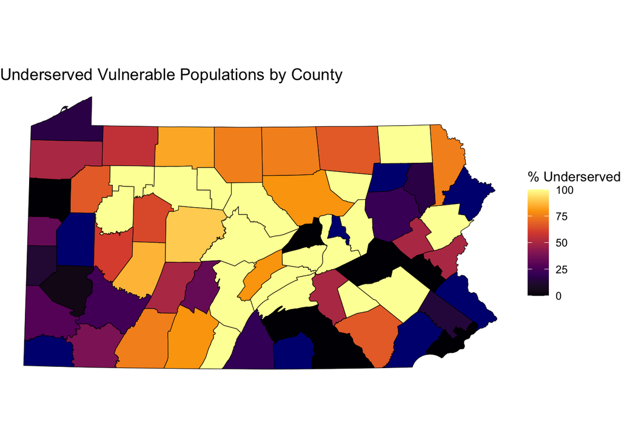

```r
#attached the summary statistics to the county boundary shapefile so it can be mapped
county_map_data <- pcounty %>%
  left_join(
    st_drop_geometry(new_spatial_join), by = "COUNTY_NAM")


#mapping underserved areas by county to observe potential patterns
ggplot() +
  geom_sf(data = county_map_data, aes(fill = pct_underserved), color = "black") +
  scale_fill_viridis_c(name = "% Underserved", na.value = "navy", option = "inferno") +
  labs(title = "Underserved Vulnerable Populations by County") +
  theme_void()
```

**Questions to answer:**.

- **Which 5 counties have the highest percentage of underserved vulnerable tracts?**.

  The vulnerable areas are further away from Philadelphia towards central PA, with more concentration in central northwest PA.